# Analysis of the mock Data

Florian Stijven

2024-04-12

# 1 Introduction

In this report, we analyze the mock data that resemble the data in the case study. These are data from a randomized trial in Alzheimer’s disease where the ADAS-Cog score has been evaluated at pre-determined measurement occasions. Additionally, baseline covariates are available; these will be adjusted for to increase efficiency.

We first read and explore the data. Next, we fit a mixed model for repeated measures (MMRM) and present the corresponding results. Finally, we use this fitted mixed model to estimate the treatment effect on the time scale with the meta time-component test (meta TCT) methodology.

# 2 Data Exploration

The Lighthouse data are read via the SAS data file. These data are in a partially long format because every post-randomization measurement has its own row, but the baseline measurement is represented by a column. For applying meta TCT, we need to fit a mixed model where the baseline measurement is also treated as a response instead of a baseline covariate. Hence, we reformat the data accordingly.

The baseline covariates and ADAS-Cog scores are summarized by treatment group in Table 2.1. By randomization, the distribution of baseline covariates should be identical across treatment groups, apart from discrepancies due to sampling variability.

Table 2.1: Patient Characteristics by Treatment Group

| **Characteristic** | **Active**, N = 272<sup>1</sup> | **Placebo**, N = 273<sup>1</sup> |
| --- | --- | --- |
| ApoE4 Stratum (N) |  |  |
| 1 | 189 (69%) | 168 (62%) |
| 2 | 83 (31%) | 105 (38%) |
| SITE |  |  |
| 1 | 5 (1.8%) | 5 (1.8%) |
| 2 | 5 (1.8%) | 7 (2.6%) |
| 3 | 12 (4.4%) | 18 (6.6%) |
| 4 | 4 (1.5%) | 6 (2.2%) |
| 5 | 7 (2.6%) | 5 (1.8%) |
| 6 | 7 (2.6%) | 5 (1.8%) |
| 7 | 9 (3.3%) | 5 (1.8%) |
| 8 | 1 (0.4%) | 5 (1.8%) |
| 9 | 12 (4.4%) | 13 (4.8%) |
| 10 | 5 (1.8%) | 1 (0.4%) |
| 11 | 3 (1.1%) | 2 (0.7%) |
| 12 | 10 (3.7%) | 14 (5.1%) |
| 13 | 5 (1.8%) | 7 (2.6%) |
| 14 | 6 (2.2%) | 8 (2.9%) |
| 15 | 18 (6.6%) | 26 (9.5%) |
| 16 | 2 (0.7%) | 6 (2.2%) |
| 17 | 7 (2.6%) | 16 (5.9%) |
| 18 | 10 (3.7%) | 8 (2.9%) |
| 19 | 6 (2.2%) | 10 (3.7%) |
| 20 | 4 (1.5%) | 4 (1.5%) |
| 21 | 15 (5.5%) | 15 (5.5%) |
| 22 | 7 (2.6%) | 6 (2.2%) |
| 23 | 11 (4.0%) | 10 (3.7%) |
| 24 | 11 (4.0%) | 3 (1.1%) |
| 25 | 6 (2.2%) | 3 (1.1%) |
| 26 | 13 (4.8%) | 5 (1.8%) |
| 27 | 11 (4.0%) | 13 (4.8%) |
| 28 | 6 (2.2%) | 3 (1.1%) |
| 29 | 28 (10%) | 23 (8.4%) |
| 30 | 7 (2.6%) | 3 (1.1%) |
| 31 | 6 (2.2%) | 5 (1.8%) |
| 32 | 13 (4.8%) | 13 (4.8%) |
| ADASCogWeek_0 | 24 (18, 28) | 22 (18, 29) |
| ADASCogWeek_12 | 24 (18, 31) | 24 (18, 31) |
| (Missing) | 3 | 11 |
| ADASCogWeek_24 | 26 (19, 32) | 25 (19, 34) |
| (Missing) | 21 | 26 |
| ADASCogWeek_40 | 28 (20, 35) | 27 (20, 36) |
| (Missing) | 40 | 45 |
| ADASCogWeek_48 | 27 (20, 36) | 27 (21, 37) |
| (Missing) | 54 | 56 |

<sup>1</sup> n (%); Median (IQR)

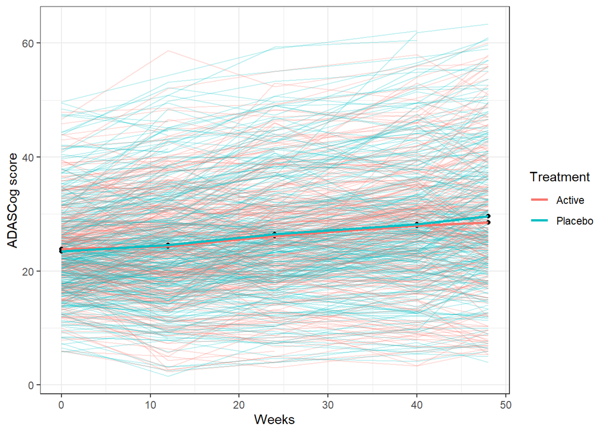

Figure 2.1: Plot of patient-specific profiles together with the treatment specific mean profiles based on a complete case analysis.

# 3 Mixed Model for Repeated Measures

We now fit a MMRM where the vector of ADAS-Cog scores at baseline, 12, 24, 40, and 48 weeks is the response variable. The model is fitted with restricted maximum likelihood. We also add the following baseline covariates in the model:

- `SITE`: This is a categorical variable for the study sites; we include a main effect for this variable.
- `AAPOEN`: This is the APOE Allele status. We include an interaction between the measurement occasion and this variable.

In this model, we also assume that the mean ADAS-Cog scores at baseline are equal between both treatment groups. This holds by randomization. The mixed model is fitted with `mmrm()` from the `mmrm` R package.

We test for a treatment effect using the F-test with the Kenward-Rogers degrees of freedom approximation.

```
## Analysis of Fixed Effect Table (Type II F tests)
##             Num Df Denom Df F Statistic   Pr(>=F)
## SITE            31   507.63       4.070 1.019e-11 ***
## AAPOEN           1   495.54       6.032   0.01439 *
## Week             4   492.99      95.489 < 2.2e-16 ***
## Week:TRT         4   490.66       2.684   0.03090 *
## AAPOEN:Week      4   490.73       2.484   0.04293 *
## ---
## Signif. codes:  0 '***' 0.001 '**' 0.01 '*' 0.05 '.' 0.1 ' ' 1
```

The p-value for the F-test is 0.031. There is thus is a significant treatment effect, but it is unclear how relevant this effect really is. A first step towards interpreting the magnitude of the treatment effect is to look at the estimated mean differences in ADAS-Cog scores.

Because we have included baseline covariates, we have to carefully define the treatment group-specific mean ADAS-Cog scores at the various measurement occasions. In what follows, we consider the estimated marginal means (EMMs, also known as least-squares means) where the factor levels of the center variable and the APOE variable receive weights proportional to their observed frequencies in the data. Alternatively, we could use equal weights for these factors, meaning that each center and APOE level receives the same weight. Which weights are most appropriate depends on whether these factors were controlled by the researchers and on the population one wishes to make inferences on.

The EMMs with proportional weights and the corresponding contrasts by measurement occasion are estimated with `emmeans()` and `contrast()` from the `emmeans` R package; the corresponding output is printed below. These contrasts indicate that the treatment effect increases with time. Still, it remains difficult to appreciate the relevance of the observed treatment effect, i.e., is a 2 points mean difference on the ADAS-Cog scale meaningful?

```
## NOTE: A nesting structure was detected in the fitted model:
##     TRT %in% Week
```

```
## Week = Week_0:
##  TRT     emmean    SE  df lower.CL upper.CL
##  Placebo   23.6 0.320 503     23.0     24.2
##
## Week = Week_12:
##  TRT     emmean    SE  df lower.CL upper.CL
##  Active    24.2 0.450 654     23.3     25.1
##  Placebo   25.0 0.451 661     24.1     25.9
##
## Week = Week_24:
##  TRT     emmean    SE  df lower.CL upper.CL
##  Active    26.2 0.490 646     25.2     27.1
##  Placebo   27.1 0.491 652     26.1     28.0
##
## Week = Week_40:
##  TRT     emmean    SE  df lower.CL upper.CL
##  Active    28.0 0.560 649     26.9     29.1
##  Placebo   29.1 0.562 655     28.0     30.2
##
## Week = Week_48:
##  TRT     emmean    SE  df lower.CL upper.CL
##  Active    28.6 0.609 645     27.4     29.8
##  Placebo   30.6 0.610 649     29.4     31.8
##
## Results are averaged over the levels of: SITE, AAPOEN
## Confidence level used: 0.95
```

```
## Week = Week_0:
##  contrast         estimate    SE  df lower.CL upper.CL
##  (nothing)          nonEst    NA  NA       NA       NA
##
## Week = Week_12:
##  contrast         estimate    SE  df lower.CL upper.CL
##  Active - Placebo   -0.761 0.425 535    -1.60   0.0744
##
## Week = Week_24:
##  contrast         estimate    SE  df lower.CL upper.CL
##  Active - Placebo   -0.897 0.462 518    -1.80   0.0101
##
## Week = Week_40:
##  contrast         estimate    SE  df lower.CL upper.CL
##  Active - Placebo   -1.130 0.584 502    -2.28   0.0180
##
## Week = Week_48:
##  contrast         estimate    SE  df lower.CL upper.CL
##  Active - Placebo   -2.062 0.649 491    -3.34  -0.7879
##
## Results are averaged over some or all of the levels of: SITE, AAPOEN
## Confidence level used: 0.95
```

# 4 Meta Time-Component Test

In this section, we will use the EMMs from the previous section to estimate the treatment effect on the time scale. We use the meta TCT methodology as implemented in the `TCT` R package for this.

In the first step, we need to extract the EMMs at all treatment-measurement occasion combinations. We also need the corresponding covariance matrix. These quantities can be obtained from the `emmGrid` object that was returned by `emmeans()`.

In the second step, we use `TCT_meta()` to estimate the measurement occasion-specific acceleration factors; the estimated acceleration factors are shown below. Note that the z-values for the estimated acceleration factors are equal to the corresponding t-values in the EMM contrasts. This is no coincidence and always holds for the `"score"` tests for the time-specific acceleration factors. The p-values below and the p-values for the EMM contrasts differ slightly because `TCT_meta()` uses the standard normal distribution instead of the t-distribution to compute the p-value.

```
## Meta-Time Component Test:
##
## Coefficients:
##   Estimate Std. Error z value  p value                  CI
## 1  0.50813   0.277135 -1.7894 0.073545 (0.013338, 1.03995)
## 2  0.78298   0.100656 -1.9427 0.052054 (0.580660, 1.00226)
## 3  0.78183   0.117791 -1.9339 0.053131 (0.585447, 1.00239)
## 4  0.75326   0.098311 -3.1796 0.001475 (0.559459, 0.91105)
## alpha = 0.05
##
## Interpolation Method: spline
## Estimation and Inference: score
```

The object returned by `TCT_meta()` can be used as argument to `TCT_meta_common()` to estimate the common acceleration factor. We use two estimation methods: (i) the score estimator with adaptively selected weights and (ii) the least-squares estimator.

```
## Meta-Time Component Test - Common Acceleration Factor:
##
## Estimated Common Acceleration Factor:
##   Estimate Std. Error z value   p value                 CI     CI (bootstrap)
## z  0.76771   0.087582 -2.8668 0.0041464 (0.59093, 0.92582) (0.59313, 0.94111)
##   p-value (bootstrap) Std. Error (bootstrap)
## z               0.014               0.089675
## alpha = 0.05
##
## Interpolation Method: spline
## Time Points Used in Estimator: 12 24 40 48
## Estimation and Inference: score
##  Type of Score Test: custom
##  Weights: 0 0.573 0 0.427
```

```
## Meta-Time Component Test - Common Acceleration Factor:
##
## Estimated Common Acceleration Factor:
##             Estimate Std. Error chi-squared   p value                 CI
## chi-squared  0.79746   0.070325      9.1944 0.0024275 (0.65637, 0.91554)
##                 CI (bootstrap) p-value (bootstrap) Std. Error (bootstrap)
## chi-squared (0.64622, 0.93817)               0.018               0.073136
## alpha = 0.05
##
## Interpolation Method: spline
## Time Points Used in Estimator: 12 24 40 48
## Estimation and Inference: least-squares
```

These two estimators lead to very similar results. The estimated common acceleration factor is about 0.77 or 0.80. The estimated treatment effect corresponds to slowing disease progression with about 20% – a very relevant effect. The p-values and confidence intervals vary a bit more between these estimators and also depend on whether the parametric bootstrap is used. Since the sample size is relatively small, the parametric bootstrap should be preferred. Indeed, simulations revealed that inference based on the parametric bootstrap is closer to nominal in small sample sizes.

# 5 Conclusion